[binary.com](https://github.com/englianhu/binary.com-interview-question) Interview Question I - Interday Betting Strategy Models Comparison (Financial Betting and Stock Market)

[®γσ, Lian Hu](https://englianhu.github.io/) ®

2018-10-31

# 1 Introduction

## 1.1 Abstract

In order to test the timeline of daily highest and lowest price, here I created this file to read the high volume tick-data-history to test the efficiency of Kelly Criterion betting models. Kindly refer to Reference for further information.

*binary.com Interview Question I - Tick-Data-HiLo For Daily Trading (Blooper)* descript that the VaR figure required in order to place orders. [What is the difference between Sharpe ratio and value at risk?](https://www.quora.com/What-is-the-difference-between-Sharpe-ratio-and-value-at-risk) states the difference between VaR and shape ratio where the shape ratio will be use in the future research.

[ARIMA+GARCH Trading Strategy on the S&P500 Stock Market Index Using R](https://www.quantstart.com/articles/ARIMA-GARCH-Trading-Strategy-on-the-SP500-Stock-Market-Index-Using-R) compares the ROI of buy and hold and application of ARIMA + GARCH model.

[Systematic Investor Blog : Trading Strategies](https://systematicinvestor.wordpress.com/category/trading-strategies/) introduce various trading strategies.

> The Sharpe ratio can also help explain whether a portfolio’s excess returns are due to smart investment decisions or a result of too much risk. Although one portfolio or fund can enjoy higher returns than its peers, it is only a good investment if those higher returns do not come with an excess of additional risk. The greater a portfolio’s Sharpe ratio, the better its risk-adjusted performance. A negative Sharpe ratio indicates that a risk-less asset would perform better than the security being analyzed.

*source : [Investopedia : Sharpe Ratio](https://www.investopedia.com/terms/s/sharperatio.asp)*

## 1.2 Intro Reference

*Currency Hedging Strategies Using Dynamic Multivariate GARCH* compares DCC, BEKK, CCC and VARMA-AGARCH models to examine the conditional volatilities among the spot and two distint futures maturities, namely near-month and next-to-near-month contracts. The estimated conditionl covariances matrices from these models were used to calculate the optimal portfolios weights and optimal hedge ratios. The empirical results in the paper reveal that there are not big differences either the near-month or next-to-near-month contract is used for hedge spot position on currencies. They also reveal that hedging ratios are lower for near-month contract when the USD/EUR and USD/JPY exchange rates are anlyzed. This result is explained in terms of the higher correlation between spot prices and the next-to-near-month future prices than that with near-month contract and additionally because of the lower volatility of the long maturity futures. Finally across all currencies and error densities, the CCC and VARMA-AGARCH models provide similar results in terms of hedging ratios, portfolio variance reduction and hedging effectiveness. Some difference might appear when the DCC and BEKK models are used. Below is the table summary of the paper.

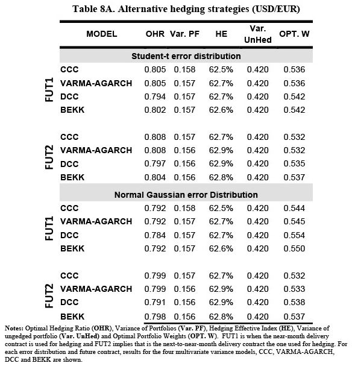

*Figure 3.1.1A : comparison of hedge strategy.*

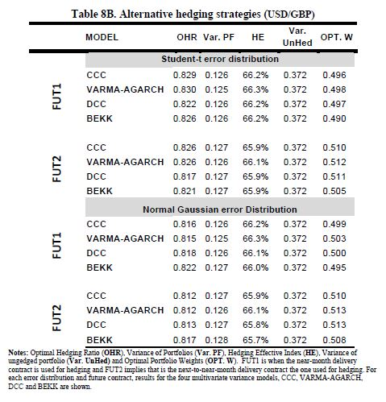

*Figure 3.1.1B : comparison of hedge strategy.*

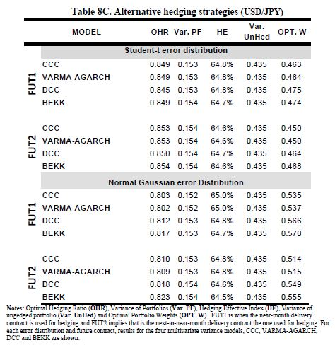

*Figure 3.1.1C : comparison of hedge strategy.*

Tables 8A-8C report the average OHR values, the hedge effectiveness, the variance of the portfolio, the hedging effectiveness along with the average value of the optimal portfolio weights for the three currencies using FUT1 and FUT2 contracts when both the Student t and normal error distributions are assumed. We show the results for the four multivariate volatility models.

Tables 8A-8C show that hedging is effective in reducing the risks for every model, currency and maturity. In particular, we find that the average OHR using FUT2 contracts are slightly higher than when FUT1 contracts are used, except for GBP. The highest average OHR value is 0.854 for USD/JPY when FUT2 contracts are used, meaning that, in order to minimize risk, a long (buy) position of one dollar in such a currency should be hedged by a short (sell) position of $0.854 in JPYFUT2 contracts.

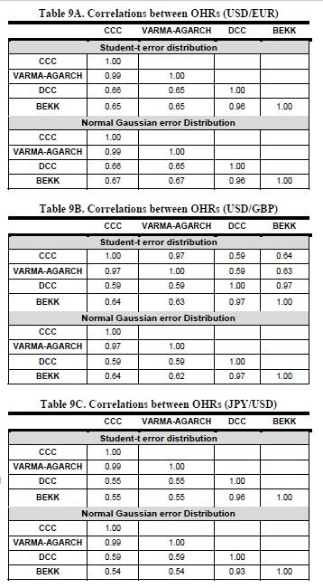

*Figure 3.1.2 : comparison of hedge strategy.*

The correlations of the dynamic patterns in Tables 8A-8C are given in Tables 9A-9C. It is clear that, across all currencies and both error densities, the OHRs are most similar between CCC and VARMA-AGARCH, which suggests that dynamic asymmetry may not be crucial empirically, and also between DCC and BEKK.

In summary, the estimates based on both OHR and optimal weight values recommend holding more FUT2 than FUT1 contracts for USD/EUR and USD/JPY spot/futures portfolios, meaning that we should increase the percentage of futures contracts for longer term portfolios when these currencies are used.

*Dynamic Portfolio Optimization using Generalized Dynamic Conditional Heteroskedastic Factor Models* studies the portfolio selection problem based on a generalized dynamic factor model (GDFM) with conditional heteroskedasticity in the idiosyncratic components. We propose a Generalized Smooth Transition Conditional Correlation (GSTCC) model for the idiosyncratic components combined with the GDFM. Among all the multivariate GARCH models that the authors propose, the generalized smooth transition conditional correlation provides the best result.

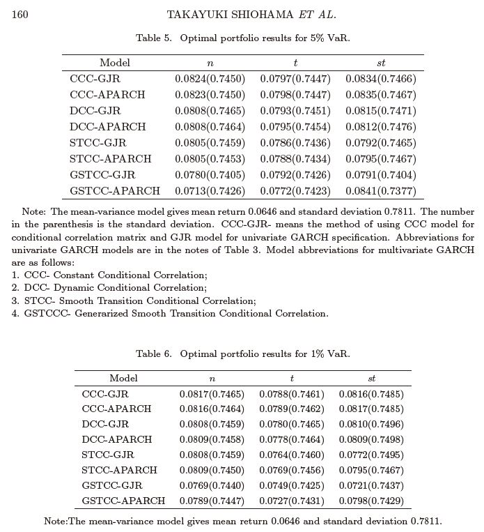

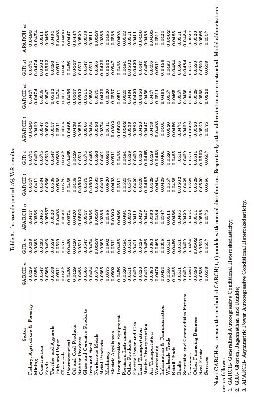

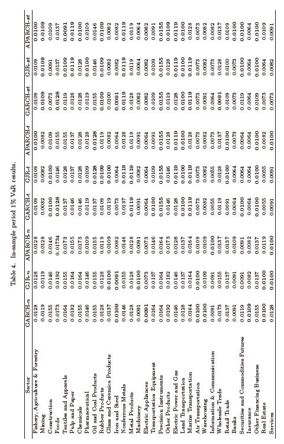

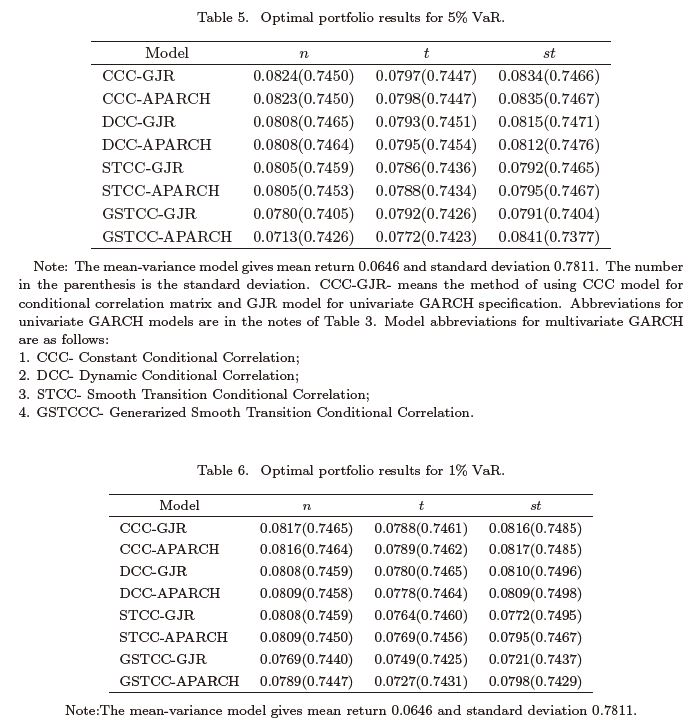

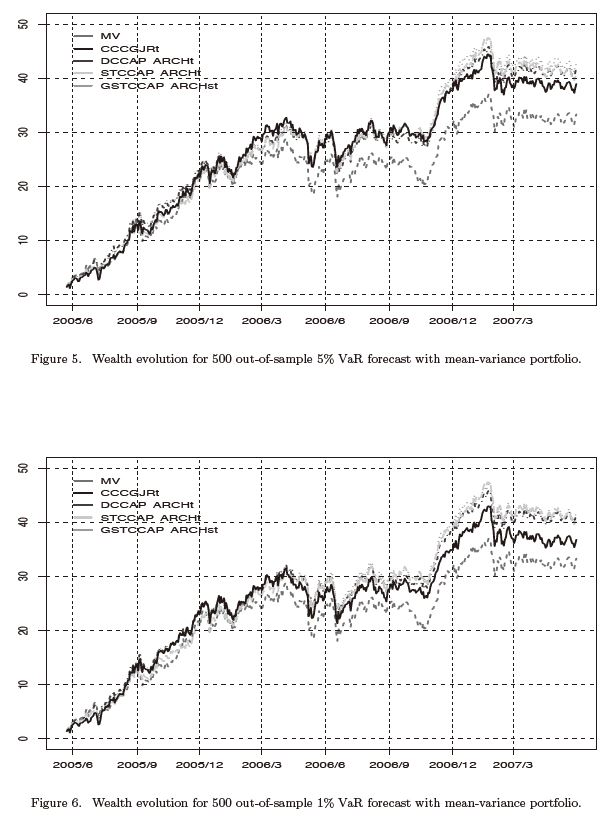

I try to surf over internet and the model has no yet widely use. Here I can only use the CCC, DCC models but the best performance GSTCC is not yet available in r packages. The `cccgarch` has STCC model but there has no examples to use it.

## 1.3 VaR

I stored the forecast VaR value as well, kindly refer to *How Good Are Your VaR Estimates?* for more information.

- *ARMA(1,1)-GARCH(1,1) Estimation and forecast using rugarch 1.2-2*
- [An Introduction to Value at Risk (VAR)](https://www.investopedia.com/articles/04/092904.asp)
- [Multivariate GARCH with respect to Value at Risk](https://stats.stackexchange.com/questions/130227/multivariate-garch-with-respect-to-value-at-risk?answertab=votes#tab-top) is the another article about VaR in multivariate models.
- [Difference between uGarchRoll Value at Risk and manual calculations](https://stats.stackexchange.com/questions/298381/difference-between-ugarchroll-value-at-risk-and-manual-calculations?answertab=votes#tab-top)
- ARMA(1,1)-GARCH(1,1) Estimation and forecast using rugarch 1.2-2
- [Issues in estimating VaR with GARCH](https://quant.stackexchange.com/questions/25946/issues-in-estimating-var-with-garch?answertab=votes#tab-top)
- [Value-At-Risk (VaR) curve with Copula-GARCH model (R)](https://stackoverflow.com/questions/40174020/value-at-risk-var-curve-with-copula-garch-model-r)
- [Calculation of VaR of a time series using a GARCH(1,1) ARMA(1,1) model](https://stats.stackexchange.com/questions/136958/calculation-of-var-of-a-time-series-using-a-garch1-1-arma1-1-model?answertab=votes#tab-top)
- [Fitting and Predicting VaR based on an ARMA-GARCH Process](https://cran.r-project.org/web/packages/qrmtools/vignettes/ARMA_GARCH_VaR.html)

```
# conditional mean
cmu = as.numeric(as.data.frame(forecast, which = "series",
rollframe="all", aligned = FALSE))
# conditional sigma
csigma = as.numeric(as.data.frame(forecast, which = "sigma",
rollframe="all", aligned = FALSE))

I can calculate the VaR by using the property, that the normal distribution
is part of the location-scale distribution families

# use location+scaling transformation property of normal distribution:
VaR = qnorm(0.01)*csigma + cmu
```

*source : [rugarch VaR calculation “manually”](http://r.789695.n4.nabble.com/rugarch-VaR-calculation-quot-manually-quot-td4666462.html)*

> 0.1262 + 1.059 * qt(0.05, 4.68) * sqrt((4.68-2) / 4.68) [1] -1.51334 Alternatively, using the rugarch package which defaults to standardized distributions:

> rugarch::qdist(“std”, 0.05, mu=0.1262, sigma=1.059, shape=4.68) [1] -1.51334

*source : [Difference between uGarchRoll Value at Risk and manual calculations](https://stats.stackexchange.com/questions/298381/difference-between-ugarchroll-value-at-risk-and-manual-calculations?answertab=votes#tab-top)*

## 1.4 VaR for Long and Short

- Value-at-Risk for long and short trading positions - Evidence from developed and emerging equity markets
- [Value-at-Risk for Long and Short Trading Positions](https://github.com/englianhu/binary.com-interview-question/blob/master/reference/Value-at-Risk%20for%20Long%20and%20Short%20Trading%20Positions.pdf)
- [Value at Risk for Long-Short Positions](https://github.com/englianhu/binary.com-interview-question/blob/master/reference/Value%20at%20Risk%20for%20Long-Short%20Positions.pdf)

# 2 Data

## 2.1 Read Data

```r
## get currency dataset online.
## http://stackoverflow.com/questions/24219694/get-symbols-quantmod-ohlc-currency-data
#'@ getFX('USD/JPY', from = '2014-01-01', to = '2017-01-20')

## getFX() doesn't shows Op, Hi, Lo, Cl price but only price. Therefore no idea to place bets.
#'@ USDJPY <- getSymbols('JPY=X', src = 'yahoo', from = '2014-01-01',
#'@                      to = '2017-01-20', auto.assign = FALSE)
#'@ names(USDJPY) <- str_replace_all(names(USDJPY), 'JPY=X', 'USDJPY')
#'@ USDJPY <- xts(USDJPY[, -1], order.by = USDJPY$Date)

cr_code <- c('AUDUSD=X', 'EURUSD=X', 'GBPUSD=X', 'CHF=X', 'CAD=X', 'CNY=X', 'JPY=X')

names(cr_code) <- c('AUDUSD', 'EURUSD', 'GBPUSD', 'USDCHF', 'USDCAD', 'USDCNY', 'USDJPY')
#'@ names(cr_code) <- c('USDAUD', 'USDEUR', 'USDGBP', 'USDCHF', 'USDCAD', 'USDCNY', 'USDJPY')

#'@ saveRDS(USDJPY, './data/USDJPY.rds')
USDJPY <- read_rds(path = './data/USDJPY.rds')
mbase <- USDJPY

## dateID
dateID <- index(mbase)
dateID0 <- ymd('2015-01-01')
dateID <- dateID[dateID > dateID0]
```

```r
dim(mbase)
```

```
## [1] 1476    6
```

```r
summary(mbase) %>%
  tidy %>%
  .[,-1] %>%
  kable(caption = 'MSE of daily Opened and Closed Transaction Orders') %>%
  kable_styling(bootstrap_options = c('striped', 'hover', 'condensed', 'responsive')) %>%
  scroll_box(width = '100%', height = '400px')
```

| Var2 | n |
| --- | --- |
| Index | Min. :2012-01-02 |
| Index | 1st Qu.:2013-05-29 |
| Index | Median :2014-10-30 |
| Index | Mean :2014-10-30 |
| Index | 3rd Qu.:2016-03-30 |
| Index | Max. :2017-08-30 |
| USDJPY.Open | Min. : 76.18 |
| USDJPY.Open | 1st Qu.: 97.86 |
| USDJPY.Open | Median :103.91 |
| USDJPY.Open | Mean :103.71 |
| USDJPY.Open | 3rd Qu.:114.27 |
| USDJPY.Open | Max. :125.60 |
| USDJPY.High | Min. : 76.20 |
| USDJPY.High | 1st Qu.: 98.29 |
| USDJPY.High | Median :104.19 |
| USDJPY.High | Mean :104.07 |
| USDJPY.High | 3rd Qu.:114.72 |
| USDJPY.High | Max. :125.82 |
| USDJPY.Low | Min. : 76.05 |
| USDJPY.Low | 1st Qu.: 97.46 |
| USDJPY.Low | Median :103.54 |
| USDJPY.Low | Mean :103.32 |
| USDJPY.Low | 3rd Qu.:113.74 |
| USDJPY.Low | Max. :124.97 |
| USDJPY.Close | Min. : 76.18 |
| USDJPY.Close | 1st Qu.: 97.85 |
| USDJPY.Close | Median :103.93 |
| USDJPY.Close | Mean :103.71 |
| USDJPY.Close | 3rd Qu.:114.24 |
| USDJPY.Close | Max. :125.63 |
| USDJPY.Volume | Min. :0 |
| USDJPY.Volume | 1st Qu.:0 |
| USDJPY.Volume | Median :0 |
| USDJPY.Volume | Mean :0 |
| USDJPY.Volume | 3rd Qu.:0 |
| USDJPY.Volume | Max. :0 |
| USDJPY.Adjusted | Min. : 76.18 |
| USDJPY.Adjusted | 1st Qu.: 97.85 |
| USDJPY.Adjusted | Median :103.93 |
| USDJPY.Adjusted | Mean :103.71 |
| USDJPY.Adjusted | 3rd Qu.:114.24 |
| USDJPY.Adjusted | Max. :125.63 |